# The Impact of Thoughts

## 1.Introduction

Philosophers provide a way to think about the world systematically. Their works influence many people potentially, providing methodology and helpful life tips. Some of their thoughts have coincided, and some are conflicted. When they develop their pieces, do other philosophers inspire them somehow? In other words, how do philosophers influence their colleagues and the history of philosophy?

In this project, we dive into the corpus philosophers wrote and research the influence of philosophers. We would approach this question with data mining techniques. We are trying to quantify and visualize their impact by examining the history of philosophy dataset from the [Philosophy Data Project](http://www.philosophydata.com/) and figuring out the influence of philosophers’ words through history.

## 2.Dataset Analysis

To get a better sense of the dataset, we first take a glimpse of the dataset.

### Column Details

- title
- author
- school
- sentence_spacy
- sentence_str
- original_publication_date
- corpus_edition_date
- sentence_length
- sentence_lowered
- tokenized_txt
- lemmatized_str

### Missing values

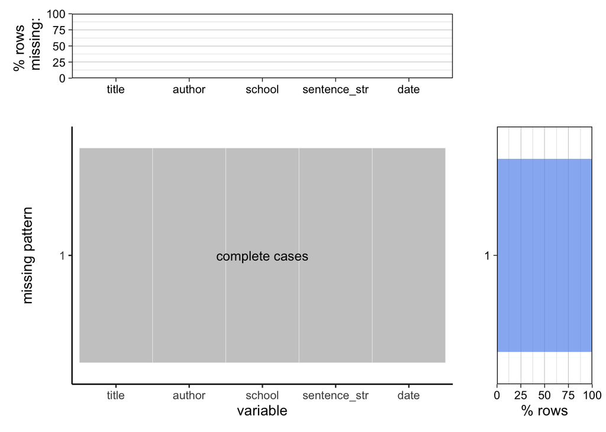

This dataset is a preprocessing dataset. Each row contains one sentence and its relative information. The above graph checks the missing value. There are no missing values, and the total contains 360808 complete sentences. We then checked unique authors, titles, and schools collected in the dataset.

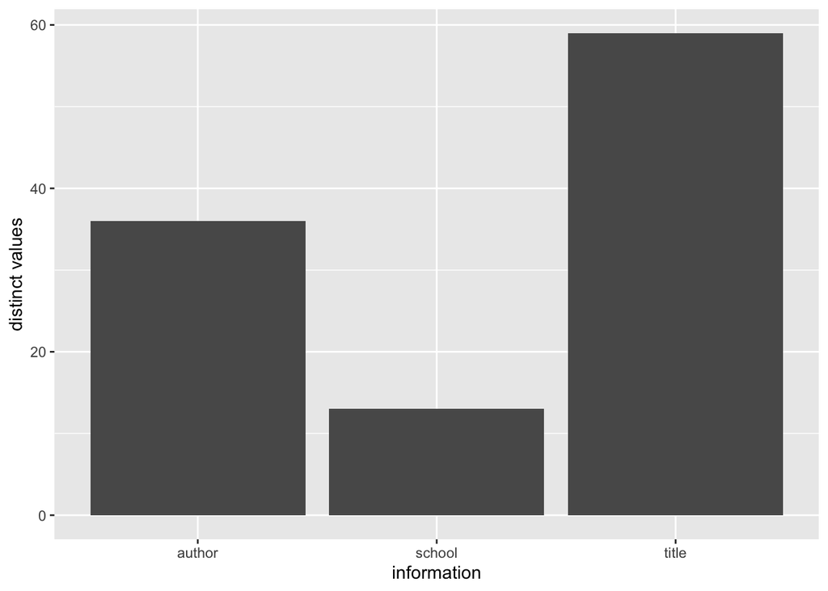

Thirteen schools and 36 distinct philosophers were recorded. 59 corpus was created and contained 360,000 sentences. We can create a word cloud to visualize the high-frequency words among all texts.

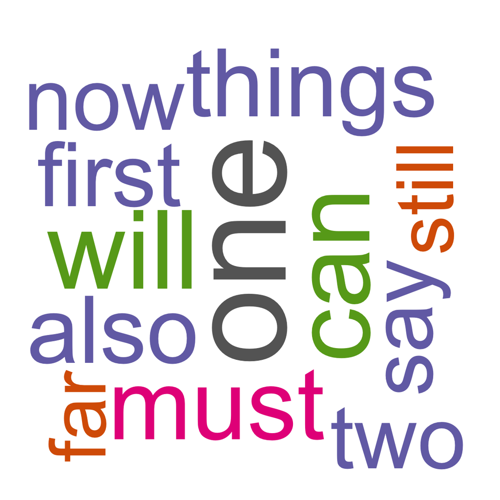

It is hard to observe the influence of any philosopher in this method since the high-frequency words are pretty simple, and the text pattern doesn’t vary much. There are no outstanding high-frequency words that point toward a specific philosopher. Hence we would try to analyze the influence of philosophers in multiple dimensions and aspects.

## 3.Influence Analysis

### Author

To find the influence of a philosopher, we can dive into the corpus and find connections. It is reasonable to speculate that if one philosopher was directly mentioned in other philosophers’ work, they are impactful among colleagues. We can count the author’s name in all texts at this stage.

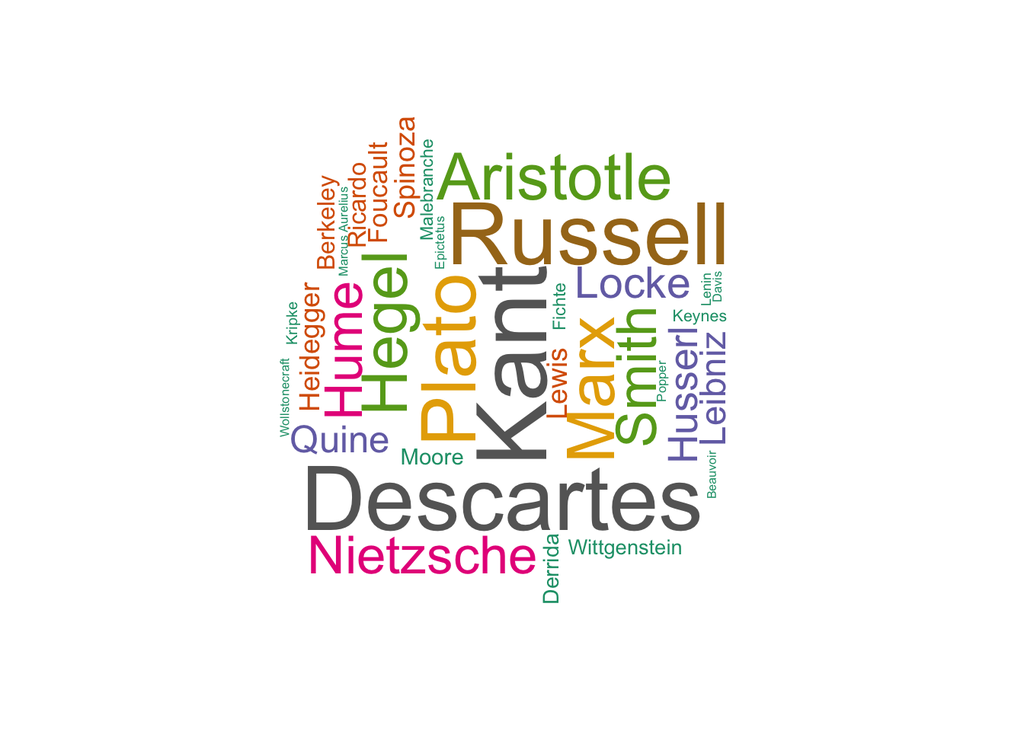

This word cloud shows the authors of the philosophy corpus in the dataset and the size displayed corresponding to the occurrence of names under corpus written by other philosophers. The famous philosophers are in the center of the cloud. We can then explore those philosophers with high occurrence by a bar chart.

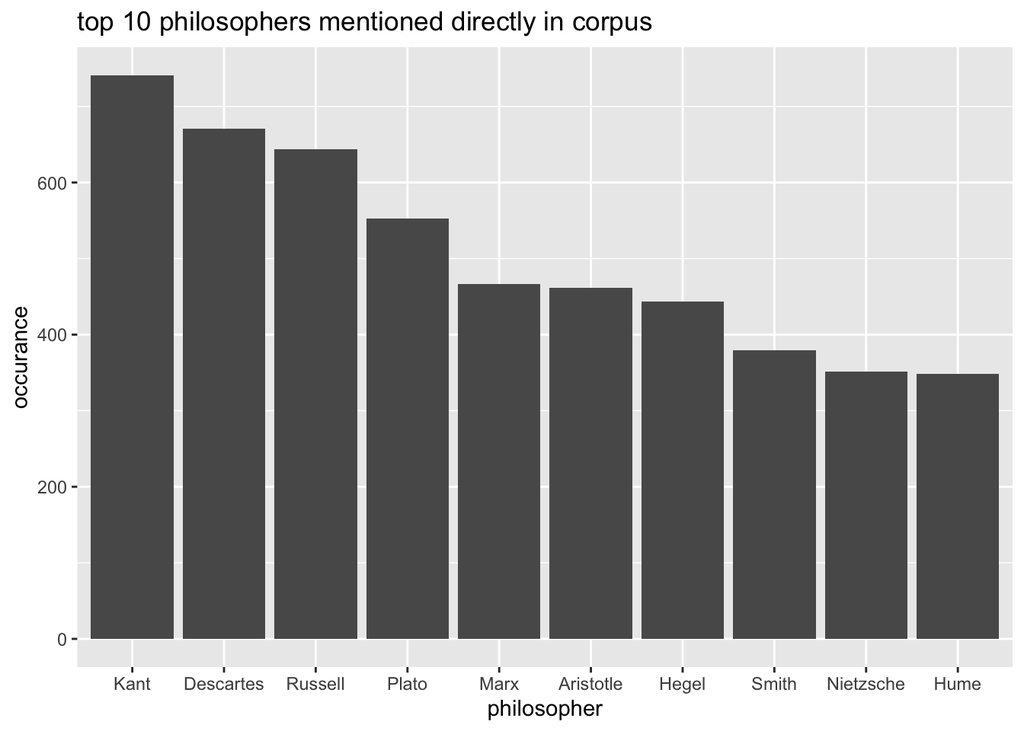

Here we plot the top 10 philosophers’ names. Intuitively, ancient philosophers should have a higher chance of being cited in the corpus. Surprisingly, the top 3 authors mentioned in corpora are not ancient Greek philosophers such as Plato and Aristotle. Instead, Kant, Descartes, and Russell are the top 3 directed recorded philosophers in the history of philosophy. We could investigate what led to this situation by examining the school’s details.

### School

Another indirect influence indicator is the appearance of the school name in texts. We could cluster the philosophers by schools and find their influence by capturing the occurrence of school in the philosophy corpora. If a school has appeared in texts multiple times, the philosophers under the category are doing works that their peers recognize.

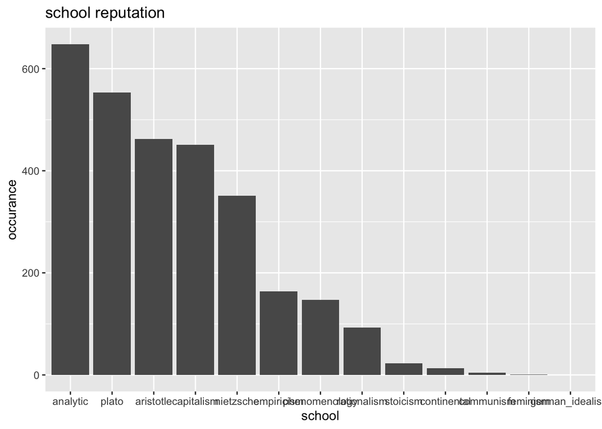

The graph shows that analytic school is widespread in other schools’ corpus. Surprisingly, German idealism, which Kant belongs to, was the least mentioned school (actually, 0 times appeared in other corpora).

### Corpus

We can further investigate the distribution of corpus via an alluvial graph and observe to what the author and school of each corpus belong.

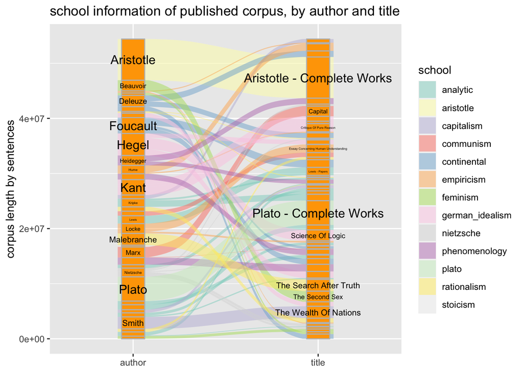

The y-axis represents the length of corpus each philosopher has written. We can observe the corpus lengths by the thickness of the rectangular box in the left bar. The stacked bar on the right represented different corpora. Aristotle is the philosopher who wrote the most. We could also follow how many canons a philosopher wrote by observing flow color. A unified color flow from author to a title means the philosopher only has one corpus. For example, Aristotle and Plato wrote a lot in a single corpus. A branched color line implies the philosopher wrote multiple corpora. We find that german idealism philosophers (Hegel and Kant) wrote many different corpora.

## 4.Conclusion

After analysis from 3 different perspectives, we can get a sense of the position of philosophers in history. Kant as a philosopher is the top philosopher directly named in other corpora. Still, his school, german idealism, is not so famous and is not even mentioned in any text. Analyze by the school; we could find that the analytics school is mentioned in other texts, implying that philosophers like Russel conduct influential research on philosophers in other schools. After analyzing the corpus with a combination of author and title information, we realize Aristotle produced the most extensive corpus in the history of philosophy (by sentence length).